# Friday Crash course

NL

# Some basics

- R is object based
- R has different types of objects: strings, vectors, matrix, data frames, list and more
- R can be used as a calculator
- R has different types of variables: numeric, strings factors etc
- Overview of layout

# Setting up a working directory

By specifying the working directory, R will know where to source the files from.

Check wd with getwd()

Set wd with setwd()

```r
getwd()
```

```
[1] "C:/Users/Nick/Documents/R project/notbsfrepo"
```

# Packages

- From Rstudio, go to the packages tab and click install
- install.packages(“ggplot2”)
- After installing and for every session, you will need to load the library again. FOr this use library(ggplot2) OR click on the check box in Rstudio but this is slow.
- vignettes!

```r
vignette()
vignette("extending-ggplot2")
```

# Importing data into R

Normally, we use csv files as its cleaner but I import xlsx files when I am lazy. This requires additional packages such as readxl. For this example, we will import in one of the fly measurements that is in the project.

```r
read.csv("phorid_data.csv")
```

| ZRC | Part | Length | Volume | Measurer |
| --- | --- | --- | --- | --- |
| ZRCBDP0000048 | Head | 0.349 | 0.01370 | NL |
| ZRCBDP0000048 | Thorax | 0.905 | 0.09440 | NL |
| ZRCBDP0000048 | Abdomen | 0.864 | 0.04850 | NL |
| ZRCBDP0000052 | Head | 0.328 | 0.01070 | NL |
| ZRCBDP0000052 | Thorax | 0.664 | 0.05670 | NL |
| ZRCBDP0000052 | Abdomen | 0.775 | 0.05800 | NL |
| ZRCBDP0000076 | Head | 0.303 | 0.01180 | NL |
| ZRCBDP0000076 | Thorax | 0.648 | 0.05870 | NL |
| ZRCBDP0000076 | Abdomen | 0.811 | 0.05710 | NL |
| ZRCBDP0000077 | Head | 0.258 | 0.00411 | NL |

[output cut: 56 more lines]

If you import like this, R will not save it. You will have to save it as an object in the environment. This allows you to call the data later. BTW #will make whatever is behind it a comment

```r
phorid_data<-read.csv("phorid_data.csv") #Saved the data as an object called phorid_data
phorid_data #Called the data I preivously saved
```

| ZRC | Part | Length | Volume | Measurer |
| --- | --- | --- | --- | --- |
| ZRCBDP0000048 | Head | 0.349 | 0.01370 | NL |
| ZRCBDP0000048 | Thorax | 0.905 | 0.09440 | NL |
| ZRCBDP0000048 | Abdomen | 0.864 | 0.04850 | NL |
| ZRCBDP0000052 | Head | 0.328 | 0.01070 | NL |
| ZRCBDP0000052 | Thorax | 0.664 | 0.05670 | NL |
| ZRCBDP0000052 | Abdomen | 0.775 | 0.05800 | NL |
| ZRCBDP0000076 | Head | 0.303 | 0.01180 | NL |
| ZRCBDP0000076 | Thorax | 0.648 | 0.05870 | NL |
| ZRCBDP0000076 | Abdomen | 0.811 | 0.05710 | NL |
| ZRCBDP0000077 | Head | 0.258 | 0.00411 | NL |

[output cut: 56 more lines]

## Inspect your data

It’s good practice to look at your data after importing to check if there are errors or if R interprets your data type wrongly. Some fucntions that can be used inclulde head(), Summary(), str(). So lets try those.

```r
head(phorid_data) #head() lists out the first 6 rows of your data. This can be changed by specifying the number of rows you want to see
```

|  | ZRC | Part | Length | Volume | Measurer |
| --- | --- | --- | --- | --- | --- |
| 1 | ZRCBDP0000048 | Head | 0.349 | 0.0137 | NL |
| 2 | ZRCBDP0000048 | Thorax | 0.905 | 0.0944 | NL |
| 3 | ZRCBDP0000048 | Abdomen | 0.864 | 0.0485 | NL |
| 4 | ZRCBDP0000052 | Head | 0.328 | 0.0107 | NL |
| 5 | ZRCBDP0000052 | Thorax | 0.664 | 0.0567 | NL |
| 6 | ZRCBDP0000052 | Abdomen | 0.775 | 0.0580 | NL |

```r
tail(phorid_data)
```

|  | ZRC | Part | Length | Volume | Measurer |
| --- | --- | --- | --- | --- | --- |
| 61 | ZRCBDP0000076_2 | Head | 0.310 | 0.0145 | NL |
| 62 | ZRCBDP0000076_2 | Thorax | 0.615 | 0.0519 | NL |
| 63 | ZRCBDP0000076_2 | Abdomen | 0.781 | 0.0645 | NL |
| 64 | ZRCBDP0000076_2 | Head | NA | NA | WT |
| 65 | ZRCBDP0000076_2 | Thorax | NA | NA | WT |
| 66 | ZRCBDP0000076_2 | Abdomen | NA | NA | WT |

```r
head(phorid_data,10)
```

|  | ZRC | Part | Length | Volume | Measurer |
| --- | --- | --- | --- | --- | --- |
| 1 | ZRCBDP0000048 | Head | 0.349 | 0.01370 | NL |
| 2 | ZRCBDP0000048 | Thorax | 0.905 | 0.09440 | NL |
| 3 | ZRCBDP0000048 | Abdomen | 0.864 | 0.04850 | NL |
| 4 | ZRCBDP0000052 | Head | 0.328 | 0.01070 | NL |
| 5 | ZRCBDP0000052 | Thorax | 0.664 | 0.05670 | NL |
| 6 | ZRCBDP0000052 | Abdomen | 0.775 | 0.05800 | NL |
| 7 | ZRCBDP0000076 | Head | 0.303 | 0.01180 | NL |
| 8 | ZRCBDP0000076 | Thorax | 0.648 | 0.05870 | NL |
| 9 | ZRCBDP0000076 | Abdomen | 0.811 | 0.05710 | NL |
| 10 | ZRCBDP0000077 | Head | 0.258 | 0.00411 | NL |

Now, it shows the first 10 rows of data.

```r
str(phorid_data)
```

```
'data.frame':   66 obs. of  5 variables:
 $ ZRC     : Factor w/ 11 levels "ZRCBDP0000048",..: 1 1 1 2 2 2 4 4 4 6 ...
 $ Part    : Factor w/ 3 levels "Abdomen","Head",..: 2 3 1 2 3 1 2 3 1 2 ...
 $ Length  : num  0.349 0.905 0.864 0.328 0.664 0.775 0.303 0.648 0.811 0.258 ...
 $ Volume  : num  0.0137 0.0944 0.0485 0.0107 0.0567 0.058 0.0118 0.0587 0.0571 0.00411 ...
 $ Measurer: Factor w/ 2 levels "NL","WT": 1 1 1 1 1 1 1 1 1 1 ...
```

str() gives you the structure of the data you imported. This one is quite useful as it tells you what kind of data R thinks the data is. For example, body part is a factor with 3 levels. In this case, R is correct in the variables we have but if the levels of the factors are numbers, it might be interpreted as numeric data. You would then have to tell R to change it.Another way to check is using is.factor().

```r
summary(phorid_data)
```

```
              ZRC          Part        Length           Volume         Measurer
 ZRCBDP0000048  : 6   Abdomen:22   Min.   :0.0000   Min.   : 0.00000   NL:33
 ZRCBDP0000052  : 6   Head   :22   1st Qu.:0.3260   1st Qu.: 0.01125   WT:33
 ZRCBDP0000075  : 6   Thorax :22   Median :0.4960   Median : 0.03010
 ZRCBDP0000076  : 6                Mean   :0.5902   Mean   : 0.23166
 ZRCBDP0000076_2: 6                3rd Qu.:0.7780   3rd Qu.: 0.06290
 ZRCBDP0000077  : 6                Max.   :3.6400   Max.   :12.10000
 (Other)        :30                NA's   :3        NA's   :3
```

This one is useful for a quick overview of your data. Counts of your facotrs and mean/quartiles.

Some other useful functions include length(), nrow(), ncol(), rep(), seq() etc. Good to familiarise yourself with these functions.

```r
a<-rep(c(1,3),3)
a
```

```
[1] 1 3 1 3 1 3
```

```r
b<-seq(1:6)
b
```

```
[1] 1 2 3 4 5 6
```

```r
length(a)
```

```
[1] 6
```

## Preparing data

I guess most of our data would be as dataframes. So ill focus on that. -To reference a column in a DF, use dataframe$colname

```r
phorid_data$Part
```

```
 [1] Head    Thorax  Abdomen Head    Thorax  Abdomen Head    Thorax  Abdomen Head    Thorax  Abdomen Head
[14] Thorax  Abdomen Head    Thorax  Abdomen Head    Thorax  Abdomen Head    Thorax  Abdomen Head    Thorax
[27] Abdomen Head    Thorax  Abdomen Head    Thorax  Abdomen Head    Thorax  Abdomen Head    Thorax  Abdomen
[40] Head    Thorax  Abdomen Head    Thorax  Abdomen Head    Thorax  Abdomen Head    Thorax  Abdomen Head
[53] Thorax  Abdomen Head    Thorax  Abdomen Head    Thorax  Abdomen Head    Thorax  Abdomen Head    Thorax
[66] Abdomen
Levels: Abdomen Head Thorax
```

You can add in new columns the same way

```r
phorid_data$newcol<-seq(1:3) #Lets say 1,2,3 are a proxy for head, thorax, abdomen respectively.
str(phorid_data) # In this case, R thinks that the newcol is an integer. We will have to change it.For that we use as.factor.
```

```
'data.frame':   66 obs. of  6 variables:
 $ ZRC     : Factor w/ 11 levels "ZRCBDP0000048",..: 1 1 1 2 2 2 4 4 4 6 ...
 $ Part    : Factor w/ 3 levels "Abdomen","Head",..: 2 3 1 2 3 1 2 3 1 2 ...
 $ Length  : num  0.349 0.905 0.864 0.328 0.664 0.775 0.303 0.648 0.811 0.258 ...
 $ Volume  : num  0.0137 0.0944 0.0485 0.0107 0.0567 0.058 0.0118 0.0587 0.0571 0.00411 ...
 $ Measurer: Factor w/ 2 levels "NL","WT": 1 1 1 1 1 1 1 1 1 1 ...
 $ newcol  : int  1 2 3 1 2 3 1 2 3 1 ...
```

```r
phorid_data$newcol<-as.factor(phorid_data$newcol)
str(phorid_data)# It is now a factor
```

```
'data.frame':   66 obs. of  6 variables:
 $ ZRC     : Factor w/ 11 levels "ZRCBDP0000048",..: 1 1 1 2 2 2 4 4 4 6 ...
 $ Part    : Factor w/ 3 levels "Abdomen","Head",..: 2 3 1 2 3 1 2 3 1 2 ...
 $ Length  : num  0.349 0.905 0.864 0.328 0.664 0.775 0.303 0.648 0.811 0.258 ...
 $ Volume  : num  0.0137 0.0944 0.0485 0.0107 0.0567 0.058 0.0118 0.0587 0.0571 0.00411 ...
 $ Measurer: Factor w/ 2 levels "NL","WT": 1 1 1 1 1 1 1 1 1 1 ...
 $ newcol  : Factor w/ 3 levels "1","2","3": 1 2 3 1 2 3 1 2 3 1 ...
```

There are also commands to change data to numeric or factors or other types.

### Selection only data you want

#### Subset

Subset lets you select data that only meets certain criteria. For example, if we are only interested in head measurements, we can remove the rest of the data. OR if we only want body parts over a certain length.

```r
phorid_head<-subset(phorid_data, phorid_data$Part=="Head")
phorid_2<-subset(phorid_data, phorid_data$Length>0.3 & phorid_data$Length <0.9)
phorid_2
```

|  | ZRC | Part | Length | Volume | Measurer | newcol |
| --- | --- | --- | --- | --- | --- | --- |
| 1 | ZRCBDP0000048 | Head | 0.349 | 0.01370 | NL | 1 |
| 3 | ZRCBDP0000048 | Abdomen | 0.864 | 0.04850 | NL | 3 |
| 4 | ZRCBDP0000052 | Head | 0.328 | 0.01070 | NL | 1 |
| 5 | ZRCBDP0000052 | Thorax | 0.664 | 0.05670 | NL | 2 |
| 6 | ZRCBDP0000052 | Abdomen | 0.775 | 0.05800 | NL | 3 |
| 7 | ZRCBDP0000076 | Head | 0.303 | 0.01180 | NL | 1 |
| 8 | ZRCBDP0000076 | Thorax | 0.648 | 0.05870 | NL | 2 |
| 9 | ZRCBDP0000076 | Abdomen | 0.811 | 0.05710 | NL | 3 |
| 11 | ZRCBDP0000077 | Thorax | 0.322 | 0.00513 | NL | 2 |
| 12 | ZRCBDP0000077 | Abdomen | 0.787 | 0.12400 | NL | 3 |

[output cut: 37 more lines]

#### Removing rows

```r
phorid_head<-phorid_head[-5:-10,]
```

#### Removing columns

Same as removing rows. Except that you use df[,-x]

```r
phorid_head<-phorid_head[,-2]
```

Second column (part) is now gone

#### Adding rows

```r
phorid_data<-phorid_data[,-7]
phorid_test<-rbind(phorid_2,phorid_data)
```

#### Add columns

```r
phorid_test<-cbind(phorid_test, 1:nrow(phorid_test))
phorid_test$Lenvol<-phorid_test$Length/phorid_test$Volume
```

-However, in this example the column name is now nonsense.

#### Renaming column

```r
colnames(phorid_test)<-c("ZRC","Part","Length","Volume","Measurer","PartProxy","rownumber", "Length/Vol")
colnames(phorid_test)[7]<-"rownum"
```

#### apply/lapply/sapply/tapply Applies a function to a object

```r
sapply(phorid_data[,3:4], FUN=sum, na.rm=T)
```

```
  Length   Volume
37.18500 14.59479
```

```r
sapply(phorid_data[,3:4], FUN=mean, na.rm=T)
```

```
   Length    Volume
0.5902381 0.2316633
```

#### Aggregate

```r
aggregate(phorid_data, by=phorid_data["Measurer"], mean)
```

[output not shown]

| Measurer | ZRC | Part | Length | Volume | Measurer | newcol |
| --- | --- | --- | --- | --- | --- | --- |
| NL | NA | NA | 0.5418788 | 0.03922515 | NA | NA |
| WT | NA | NA | NA | NA | NA | NA |

```r
aggregate(phorid_data, by=phorid_data["Measurer"], mean, na.rm=T)
```

[output not shown]

| Measurer | ZRC | Part | Length | Volume | Measurer | newcol |
| --- | --- | --- | --- | --- | --- | --- |
| NL | NA | NA | 0.5418788 | 0.03922515 | NA | NA |
| WT | NA | NA | 0.6434333 | 0.44334533 | NA | NA |

```r
meanvol<-aggregate(Volume~Measurer+ZRC, phorid_data, mean, na.rm=T) #another way
```

#### Loops

[figure not shown]

Loops

- I’ve only ever used for loops.
- Basic structure is:

for (i in x:y){

function(i)

}

```r
for (i in 1:10){
  if (i <5) print(i)
}
```

```
[1] 1
[1] 2
[1] 3
[1] 4
```

```r
for (j in 1:10){
  ifelse(j>=4, print(j), print("less than 4"))
}
```

```
[1] "less than 4"
[1] "less than 4"
[1] "less than 4"
[1] 4
[1] 5
[1] 6
[1] 7
[1] 8
[1] 9
[1] 10
```

- There are other useful fucntions which you should try and explore.
- Some packages have functions that do very similar stuff but the code might be simpler
- For data prep, the dplyr package is very useful but the code is quite different from normal R.

## EDA

- Good place to start would be Excel Ideas.
- Really depends on what data you have.
- Can start with scatter plots, boxplots, correlation matrix, histograms. Going to try base R first
- Usually plot() is smart enough to detect what kind of plot to draw depending on variable type.

#### Boxplot

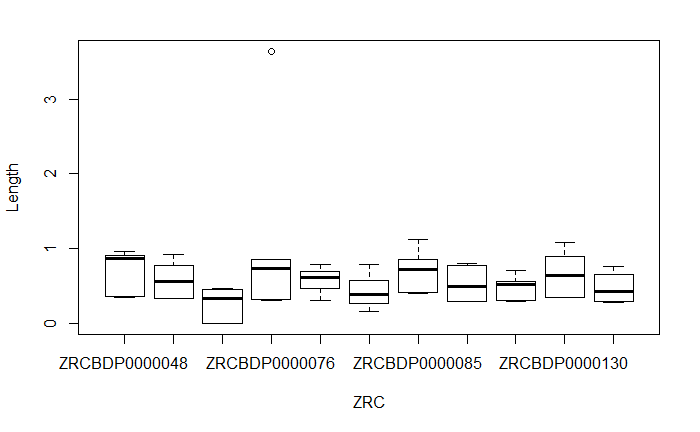

- Take note, its always **y~x**.

#### scatter plots

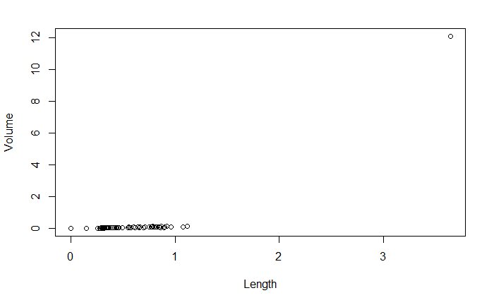

- One outlier is making the visualisation useless so lets remove it from the graph.

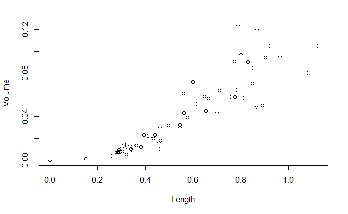

#### Correlation matrix

```r
cor(phorid_data[,3:4], use="complete.obs")
```

```
          Length    Volume
Length 1.0000000 0.8475445
Volume 0.8475445 1.0000000
```

- cor() Lets you see the correlation between the numeric variables.
- Going to use corrplot package to visualise it and a bigger, cleaner dataset.

```r
library(corrplot)
```

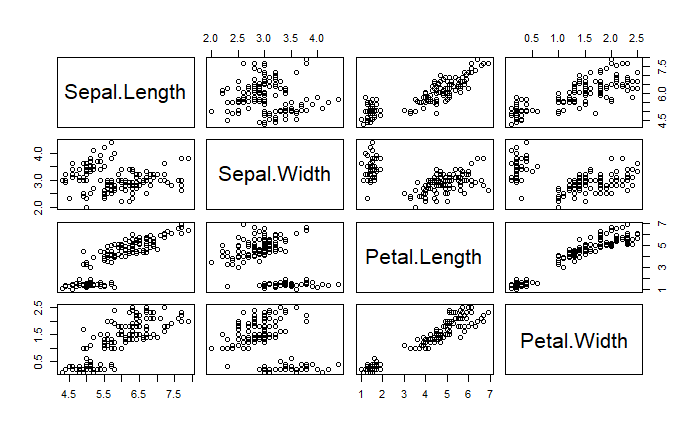

- Corrplot needs the corelation matrix to plot. So we have to extract it first.

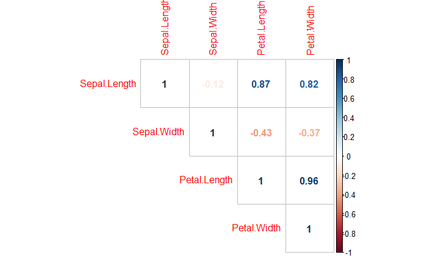

# Modelling

- Skipping for now. Check out lm() and aov() for linear models and anova.

# Plotting

- Highly recommend ggplot2 if you want to make nicer, more flexible plots than in base r
- Code looks complicated but it is actually quite simple.
- Basic structure is to use ggplot(data, aes(x=,y= )) to initialise the plot
- THis tells R where to get the data from and what to put on each axis
- But unlike plot(), ggplot will not add in the charts, you will have to specify the types of plot you want.
- Check out the [ggplot2 cheat sheet](https://rstudio.com/wp-content/uploads/2015/03/ggplot2-cheatsheet.pdf)
- Common ones include:
  - geom_point()
  - geom_bar()
  - geom_boxplot()
  - geom_line()/hline/vline/abline

-Other things to include: * facet_wrap() * labs() * xlim/ylim() * scale

- Lets try an example

```r
phorid_data$body_length
```

[output not shown]